# INFO201_Project_Kasetcharoenkit_Khawton

## Data Set 2: Agriculture Area

### Load the Data

Download the data that you want to use, and load it as a data frame in R below. Give it some kind of name. Display a summary of the data.

```r
Agricultural_Area <- read.csv("ArgriculturalArea.csv")
Agricultural_Area |>
   glimpse()
```

```
Rows: 271
Columns: 16
$ Series.Name    <chr> "Agricultural land (% of land area)", "Agricultural lan…
$ Series.Code    <chr> "AG.LND.AGRI.ZS", "AG.LND.AGRI.ZS", "AG.LND.AGRI.ZS", "…
$ Country.Name   <chr> "Afghanistan", "Albania", "Algeria", "American Samoa", …
$ Country.Code   <chr> "AFG", "ALB", "DZA", "ASM", "AND", "AGO", "ATG", "ARG",…
$ X1990..YR1990. <chr> "58.3229842233568", "40.9124087591241", "16.23854828822…
$ X2000..YR2000. <chr> "57.9458166597673", "41.7518248175182", "16.80326148110…
$ X2014..YR2014. <chr> "58.123668031216", "42.857299270073", "17.3952656461243…
$ X2015..YR2015. <chr> "58.123668031216", "42.8576642335766", "17.405922810246…
$ X2016..YR2016. <chr> "58.123668031216", "43.1277372262774", "17.365532188428…
$ X2017..YR2017. <chr> "58.123668031216", "42.8569708029197", "17.355010809319…
$ X2018..YR2018. <chr> "58.2769881790166", "42.8496715328467", "17.35656798955…
$ X2019..YR2019. <chr> "58.2769881790166", "42.8467153284672", "17.34700414528…
$ X2020..YR2020. <chr> "58.7415482268525", "42.538503649635", "17.347004145287…
$ X2021..YR2021. <chr> "58.7415482268525", "41.471897810219", "17.347004145287…
$ X2022..YR2022. <chr> "..", "..", "..", "..", "..", "..", "..", "..", "..", "…
$ X2023..YR2023. <chr> "..", "..", "..", "..", "..", "..", "..", "..", "..", "…
```

```r
Agricultural_Area |>
  summary()
```

```
 Series.Name        Series.Code        Country.Name       Country.Code
 Length:271         Length:271         Length:271         Length:271
 Class :character   Class :character   Class :character   Class :character
 Mode  :character   Mode  :character   Mode  :character   Mode  :character
 X1990..YR1990.     X2000..YR2000.     X2014..YR2014.     X2015..YR2015.
 Length:271         Length:271         Length:271         Length:271
 Class :character   Class :character   Class :character   Class :character
 Mode  :character   Mode  :character   Mode  :character   Mode  :character
 X2016..YR2016.     X2017..YR2017.     X2018..YR2018.     X2019..YR2019.
 Length:271         Length:271         Length:271         Length:271
 Class :character   Class :character   Class :character   Class :character
 Mode  :character   Mode  :character   Mode  :character   Mode  :character
 X2020..YR2020.     X2021..YR2021.     X2022..YR2022.     X2023..YR2023.
 Length:271         Length:271         Length:271         Length:271
 Class :character   Class :character   Class :character   Class :character
 Mode  :character   Mode  :character   Mode  :character   Mode  :character
```

### Name

We will use this short name to refer to this data set:

- AgriculturalArea

### Data Availability

The data is available for download from:

- [Food and Agriculture Organization](https://data.worldbank.org/indicator/AG.LND.AGRI.ZS?end=2021&name_desc=false&start=1990&view=chart&year_high_desc=true)

### Question that this data set could answer

- How has the agricultural area ( % compared to the Total Land Area) of Asia continent changed from 2014 to 2021?

### Observations

- All agencies known to conduct agricultural research in a given country, including government, nonprofit, and higher education agencies. Private-for profit sector is limited and is excluded to the data set.
- The agricultural land use by total population of each particular countries
- The private sectors are not being included in the samples, which means, the samples are not representative for the whole population since my population must included individuals from public agricultural research (government, nonprofit, and higher education agencies) and private-for-profit organizations.

### Variables

- XYear..YRYear (The value associated with each year)
  - Human-readable name and description of what it represents (1 sentence): Argricultural_Area: This the agricultural area (% to the total land area) in every year since 2014 to 2021 for every countries in the world.
  - Why it matters for the question (1 sentence): This is the dependent variable for the reserach question
  - This variable includes *numbers*/*categories*/*text* with sample values being: Portion (in terms of percentage)
- XYear..YRYear (The year itself)
  - Human-readable name and description of what it represents (1 sentence): Years: This is the years that recorded from 2014 to 2021
  - Why it matters for the question (1 sentence): This is the independent variable in the research questions.
  - This variable includes *numbers*/*categories*/*text* with sample values being: Year (2014 - 2021)
- Country.Name
  - Human-readable name and description of what it represents (1 sentence): Countries: This is the list of countries that corresponds to the above agricultural area data.
  - Why it matters for the question (1 sentence): This is to use to make conclusions about Asia continents
  - This variable includes *numbers*/*categories*/*text* with sample values being: Countries names

### Looking Forward

- Using mutate to create new columns for Year. Combines countries in Asia continents and average out the agricultural area data from every countries. Make a graph comparing agricultural area data in Asia continents with time (in years).

### Step 1. Filter the countries:

```r
library(dplyr)

asian_countries <- c(
  "Afghanistan", "Armenia", "Azerbaijan", "Bahrain", "Bangladesh",
  "Bhutan", "Brunei Darussalam", "Cambodia", "China", "Cyprus",
  "Georgia", "India", "Indonesia", "Iran, Islamic Rep.", "Iraq",
  "Israel", "Japan", "Jordan", "Kazakhstan", "Kuwait",
  "Kyrgyz Republic", "Lao PDR", "Lebanon", "Malaysia", "Maldives",
  "Mongolia", "Myanmar", "Nepal", "Oman", "Pakistan",
  "Philippines", "Qatar", "Russian Federation", "Saudi Arabia",
  "Singapore", "Korea, Dem. People's Rep.", "Korea, Rep.",
  "Sri Lanka", "Syrian Arab Republic", "Taiwan",
  "Hong Kong SAR, China", "Macau SAR, China", "Tajikistan",
  "Thailand", "Timor-Leste", "Turkiye", "Turkmenistan",
  "United Arab Emirates", "Uzbekistan", "Viet Nam", "Yemen, Rep."
)

# Filter
asian_data <- Agricultural_Area %>%
  filter(Country.Name %in% asian_countries)

asian_data
```

```
                          Series.Name    Series.Code              Country.Name
1  Agricultural land (% of land area) AG.LND.AGRI.ZS               Afghanistan
2  Agricultural land (% of land area) AG.LND.AGRI.ZS                   Armenia
3  Agricultural land (% of land area) AG.LND.AGRI.ZS                Azerbaijan
4  Agricultural land (% of land area) AG.LND.AGRI.ZS                   Bahrain
5  Agricultural land (% of land area) AG.LND.AGRI.ZS                Bangladesh
6  Agricultural land (% of land area) AG.LND.AGRI.ZS                    Bhutan
7  Agricultural land (% of land area) AG.LND.AGRI.ZS         Brunei Darussalam
8  Agricultural land (% of land area) AG.LND.AGRI.ZS                  Cambodia
9  Agricultural land (% of land area) AG.LND.AGRI.ZS                     China
10 Agricultural land (% of land area) AG.LND.AGRI.ZS                    Cyprus
11 Agricultural land (% of land area) AG.LND.AGRI.ZS                   Georgia
12 Agricultural land (% of land area) AG.LND.AGRI.ZS      Hong Kong SAR, China
13 Agricultural land (% of land area) AG.LND.AGRI.ZS                     India
14 Agricultural land (% of land area) AG.LND.AGRI.ZS                 Indonesia
```

[output cut: 235 more lines]

### Step 2. Filter the year to corresponding rows:

```r
year_columns <- c("X2014..YR2014.", "X2015..YR2015.", "X2016..YR2016.",
                  "X2017..YR2017.", "X2018..YR2018.", "X2019..YR2019.",
                  "X2020..YR2020.", "X2021..YR2021.")

# convert to numeric
asian_data[year_columns] <- lapply(asian_data[year_columns], function(x) as.numeric(gsub(",", "", x)))

asian_data[year_columns]
```

```
   X2014..YR2014. X2015..YR2015. X2016..YR2016. X2017..YR2017. X2018..YR2018.
1      58.1236680     58.1236680     58.1236680     58.1236680     58.2769882
2      59.0340710     58.8935722     58.8970847     58.8724974     58.9146470
3      57.7005432     57.7017529     57.7355752     57.7956014     57.8253926
4      10.9338521     10.6940874     10.5519897     10.3974359     10.4113111
5      71.5986787     72.4763002     73.1136975     73.4526389     73.9594377
6      13.7891230     13.7891230     13.6063339     13.4490352     13.4504457
7       2.5426945      2.5426945      2.5426945      2.5426945      2.5426945
8      31.7350787     31.9942669     32.2931113     32.7675725     33.1740528
9      55.8632630     55.7831306     55.7030041     55.6228717     55.5427392
10     11.7943723     13.7099567     11.8387446     13.1406926     14.3340801
11     34.7675925     34.7978126     34.4510001     34.3186070     34.1660671
12      4.8571429      4.8571429      4.7619048      4.8571429      4.7619048
13     60.4495508     60.4317248     60.3991000     60.2839388     60.2435647
14     30.5189987     30.7853076     31.7972814     33.7147054     34.0342761
```

[output cut: 85 more lines]

### Step 3. Determine Average Argricultural Area for each year:

Calculate the average percentage of the countries in Asian continents by each year from 2014 - 2021:

```r
asian_avg_by_year <- asian_data %>%
  summarise(
    avg_2014 = mean(X2014..YR2014., na.rm = TRUE),
    avg_2015 = mean(X2015..YR2015., na.rm = TRUE),
    avg_2016 = mean(X2016..YR2016., na.rm = TRUE),
    avg_2017 = mean(X2017..YR2017., na.rm = TRUE),
    avg_2018 = mean(X2018..YR2018., na.rm = TRUE),
    avg_2019 = mean(X2019..YR2019., na.rm = TRUE),
    avg_2020 = mean(X2020..YR2020., na.rm = TRUE),
    avg_2021 = mean(X2021..YR2021., na.rm = TRUE)
  )

asian_avg_long <- data.frame(
  Year = c(2014, 2015, 2016, 2017, 2018, 2019, 2020, 2021),
  Average_Agricultural_Area = as.numeric(asian_avg_by_year)
)

print(asian_avg_long)
```

```
  Year Average_Agricultural_Area
1 2014                  34.90846
2 2015                  35.07840
3 2016                  35.10315
4 2017                  35.26590
5 2018                  35.29787
6 2019                  35.30870
7 2020                  35.35072
8 2021                  35.33283
```

### Step 4. Visualization

### Using scatter plot + Pearson value R to show how the coefficient:

```r
library(ggplot2)

scatter_data <- asian_data %>%
  select(Country.Name, X2014..YR2014., X2021..YR2021.)

scatter_data <- scatter_data %>%
  filter(!is.na(X2014..YR2014.) & !is.na(X2021..YR2021.))

colnames(scatter_data) <- c("Country", "Agricultural_Area_2014", "Agricultural_Area_2021")

head(scatter_data)
```

```
      Country Agricultural_Area_2014 Agricultural_Area_2021
1 Afghanistan               58.12367               58.74155
2     Armenia               59.03407               58.82754
3  Azerbaijan               57.70054               57.84150
4     Bahrain               10.93385               10.25316
5  Bangladesh               71.59868               77.34501
6      Bhutan               13.78912               13.45045
```

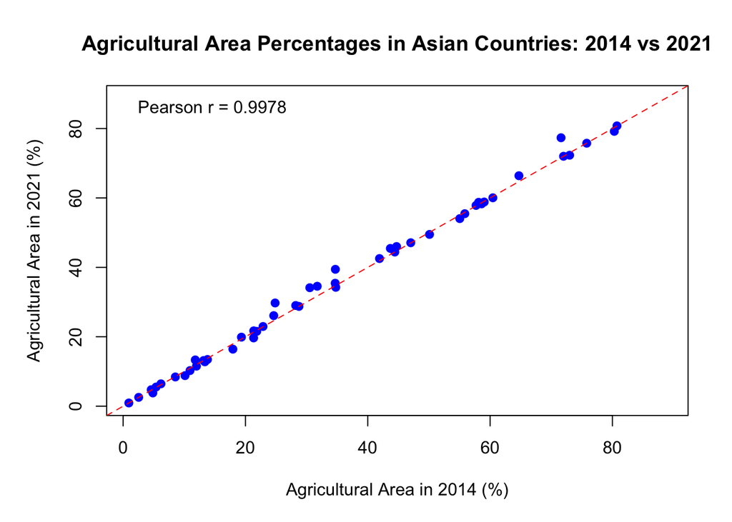

```r
par(mar = c(5, 5, 4, 2) + 0.1)

plot(
  scatter_data$Agricultural_Area_2014,
  scatter_data$Agricultural_Area_2021,
  xlab = "Agricultural Area in 2014 (%)",
  ylab = "Agricultural Area in 2021 (%)",
  main = "Agricultural Area Percentages in Asian Countries: 2014 vs 2021",
  pch = 19,
  col = "blue",
  xlim = c(min(scatter_data$Agricultural_Area_2014, scatter_data$Agricultural_Area_2021) * 0.9,
           max(scatter_data$Agricultural_Area_2014, scatter_data$Agricultural_Area_2021) * 1.1),
  ylim = c(min(scatter_data$Agricultural_Area_2014, scatter_data$Agricultural_Area_2021) * 0.9,
           max(scatter_data$Agricultural_Area_2014, scatter_data$Agricultural_Area_2021) * 1.1)
)

abline(a = 0, b = 1, col = "red", lty = 2)

# Add the correlation coefficient Pearson r
correlation <- cor(
  scatter_data$Agricultural_Area_2014,
  scatter_data$Agricultural_Area_2021,
  method = "pearson"
)

legend(
  "topleft",
  legend = paste("Pearson r =", round(correlation, 4)),
  bty = "n"
)
```

```r
  alt_text <- paste(
  "A scatter plot shows the comparation on percentage between 2014 and 2021 in agricultual area by the listed Asian countries. Also a Pearson r value shows a strong positive linear relationship, interpretating that countries with higher agricultural area percentages in 2014 generally maintained high percentages in 2021."
  )
```

# Conclusion:

## Combining two data visualization (Line Graph):

The line graph visualizations from two data sets are used to combine to answer the research question:

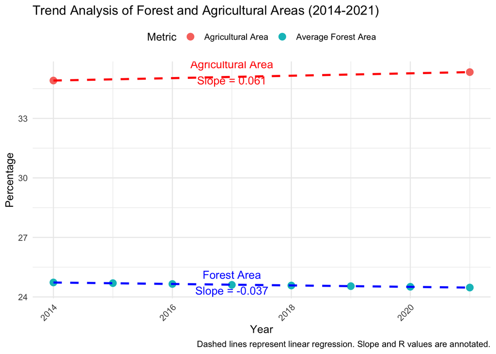

```r
library(ggplot2)

# Data preparation
forest_area_data <- data.frame(
  Year = years,
  Metric = "Average Forest Area",
  Value = average_forest_area
)

agricultural_area_data <- data.frame(
  Year = c(2014, 2021),
  Metric = "Agricultural Area",
  Value = c(
    mean(scatter_data$Agricultural_Area_2014),
    mean(scatter_data$Agricultural_Area_2021)
  )
)

# Combine both datasets
combined_data <- rbind(forest_area_data, agricultural_area_data)

# Calculate linear regression and correlation for forest area
forest_model <- lm(Value ~ Year, data = forest_area_data)
forest_slope <- round(coef(forest_model)["Year"], 3)
forest_correlation <- round(cor(forest_area_data$Year, forest_area_data$Value), 3)

# Calculate linear regression and correlation for agricultural area
agriculture_model <- lm(Value ~ Year, data = agricultural_area_data)
agriculture_slope <- round(coef(agriculture_model)["Year"], 3)
agriculture_correlation <- round(cor(agricultural_area_data$Year, agricultural_area_data$Value), 3)

# Plot
ggplot(combined_data, aes(x = Year, y = Value, color = Metric)) +
  geom_point(size = 3) +  # Data points
  geom_smooth(
    data = forest_area_data,
    aes(x = Year, y = Value),
    method = "lm",
    se = FALSE,
    color = "blue",
    linetype = "dashed"
  ) +  # Regression line for forest area
  geom_smooth(
    data = agricultural_area_data,
    aes(x = Year, y = Value),
    method = "lm",
    se = FALSE,
    color = "red",
    linetype = "dashed"
  ) +  # Regression line for agricultural area
  annotate(
    "text",
    x = 2017, y = max(forest_area_data$Value),
    label = paste("Forest Area\nSlope =", forest_slope),
    color = "blue",
    size = 4
  ) +
  annotate(
    "text",
    x = 2017, y = max(agricultural_area_data$Value),
    label = paste("Agricultural Area\nSlope =", agriculture_slope),
    color = "red",
    size = 4
  ) +
  labs(
    title = "Trend Analysis of Forest and Agricultural Areas (2014-2021)",
    x = "Year",
    y = "Percentage",
    color = "Metric",
    caption = "Dashed lines represent linear regression. Slope and R values are annotated."
  ) +
  theme_minimal() +
  theme(
    axis.text.x = element_text(angle = 45, hjust = 1),
    legend.position = "top"
  )
```

```r
  alt_text <- paste(
    "The visualization compares trends in forest area and agricultural area percentages in Asia from 2014 to 2021.",
    "It features a scatterplot with blue points representing average forest area and red points representing average agricultural area.",
    "Dashed linear regression lines show the trends: forest area decreases with a slope of", forest_slope,
    "The x-axis represents the years (2014-2021), and the y-axis represents percentages.",
    "This visualization highlights the inverse relationship between forest and agricultural areas over time."
  )
```

## Combining two data visualization (Bar Graph):

The bar graphs visualizations from two data sets are used to combine to answer the research question:

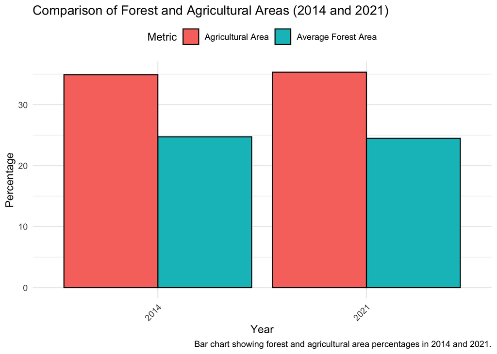

```r
library(ggplot2)

# Data preparation for forest area
forest_area_data <- data.frame(
  Year = years,
  Metric = "Average Forest Area",
  Value = average_forest_area
)

# Data preparation for agricultural area
agricultural_area_data <- data.frame(
  Year = c(2014, 2021),
  Metric = "Agricultural Area",
  Value = c(
    mean(scatter_data$Agricultural_Area_2014),
    mean(scatter_data$Agricultural_Area_2021)
  )
)

# Combine the data for both metrics into one dataset
bar_plot_data <- rbind(forest_area_data, agricultural_area_data)

# Ensure 'Year' is numeric or character for filtering
bar_plot_data$Year <- as.numeric(as.character(bar_plot_data$Year))

# Filter the data for only 2014 and 2021
filtered_data <- subset(bar_plot_data, Year %in% c(2014, 2021))

# Plot the bar graph
ggplot(filtered_data, aes(x = factor(Year), y = Value, fill = Metric)) +
  geom_bar(stat = "identity", position = "dodge", color = "black") +
  labs(
    title = "Comparison of Forest and Agricultural Areas (2014 and 2021)",
    x = "Year",
    y = "Percentage",
    fill = "Metric",
    caption = "Bar chart showing forest and agricultural area percentages in 2014 and 2021."
  ) +
  theme_minimal() +
  theme(
    axis.text.x = element_text(angle = 45, hjust = 1),
    legend.position = "top"
  )
```

## Further Research:

- The inverse relationship between forest area and agricultural area suggests a potential association between these two variables. Further research is needed to explore this connection in detail. It is hypothesized that as forest area decreases over time, agricultural area increases. This trend may be driven by population growth, which leads to greater demand for food and consequently, an expansion of agricultural land. This expansion often comes at the expense of forested regions, contributing to a reduction in the world’s finite forest resources.